# IABE Data Science Certificate - Module 1 - Assignment

## GLM Frequency and Severity

### Trainee name: Marino San Lorenzo

# Agenda

- Chapter 1 - Data Exploration
  - 1.1 univariate analysis of numerical data
  - 1.2 univariate analysis of categorical data
  - 1.3 bivariate analysis of numerical data
  - 1.4 bivariate analysis of categorical data
- Chapter 2 - Feature Engineering
  - 2.1 Processing with Binning continuous variables
    - 2.1.1 Dummy Coding with reference class
- Chapter 3 - Modelling
  - 3.1 GLM Frequency
  - 3.2 GLM Severity
  - 3.3 Elastic Net (lasso)
    - 3.3.1 Lasso Frequency
    - 3.3.2 Lasso Severity

```python
import numpy as np
import pandas as pd
from src.constants import Constants, params

from src.styling import *
from src.utils import *
from src.plots import *
import seaborn as sns
import matplotlib.pyplot as plt
from IPython.core.interactiveshell import InteractiveShell
import warnings
from sklearn.model_selection import train_test_split
import statsmodels.api as sm
import statsmodels.formula.api as smf
from tqdm import tqdm
from sklearn.metrics import mean_poisson_deviance, mean_gamma_deviance
from collections import defaultdict
```

```python
warnings.filterwarnings("ignore")
pd.set_option('display.max_colwidth', 1000)
pd.set_option('display.float_format','{:,.2f}'.format)
```

```python
df = pd.read_csv(params.get(Constants.URL_LINK_TO_DATA), delimiter = ",")
df.head()
```

|  | AGEPH | CODPOSS | duree | lnexpo | nbrtotc | nbrtotan | chargtot | agecar | sexp | fuelc | split | usec | fleetc | sportc | coverp | powerc |
| --- | --- | --- | --- | --- | --- | --- | --- | --- | --- | --- | --- | --- | --- | --- | --- | --- |
| 0 | 64 | 1000 | 1.00 | 0.00 | 0 | 0.00 | 0.00 | 2-5 | Female | Petrol | Once | Private | No | No | MTPL+ | 66-110 |
| 1 | 28 | 1000 | 0.05 | -3.07 | 1 | 21.47 | 155.97 | 6-10 | Female | Petrol | Twice | Private | No | No | MTPL | 66-110 |
| 2 | 58 | 1000 | 0.40 | -0.91 | 0 | 0.00 | 0.00 | >10 | Female | Petrol | Thrice | Private | No | No | MTPL | <66 |
| 3 | 37 | 1030 | 0.17 | -1.77 | 0 | 0.00 | 0.00 | 2-5 | Female | Petrol | Once | Professional | No | No | MTPL+++ | 66-110 |
| 4 | 29 | 1030 | 1.00 | 0.00 | 0 | 0.00 | 0.00 | 6-10 | Female | Petrol | Once | Private | No | No | MTPL+ | <66 |

# 1. Data Exploration

```python
df.info()
```

```
<class 'pandas.core.frame.DataFrame'>
RangeIndex: 163657 entries, 0 to 163656
Data columns (total 16 columns):
 #   Column    Non-Null Count   Dtype
---  ------    --------------   -----
 0   AGEPH     163657 non-null  int64
 1   CODPOSS   163657 non-null  int64
 2   duree     163657 non-null  float64
 3   lnexpo    163657 non-null  float64
 4   nbrtotc   163657 non-null  int64
 5   nbrtotan  163657 non-null  float64
 6   chargtot  163657 non-null  float64
 7   agecar    163657 non-null  object
 8   sexp      163657 non-null  object
 9   fuelc     163657 non-null  object
 10  split     163657 non-null  object
 11  usec      163657 non-null  object
 12  fleetc    163657 non-null  object
 13  sportc    163657 non-null  object
 14  coverp    163657 non-null  object
 15  powerc    163657 non-null  object
dtypes: float64(4), int64(3), object(9)
memory usage: 20.0+ MB
```

```python
summary = df.describe()
summary.style.applymap(highlight_col, subset=pd.IndexSlice[['mean', 'max'], [params.get(Constants.NB_CLAIMS)]])
summary
```

|  | AGEPH | CODPOSS | duree | lnexpo | nbrtotc | nbrtotan | chargtot |
| --- | --- | --- | --- | --- | --- | --- | --- |
| count | 163,657.00 | 163,657.00 | 163,657.00 | 163,657.00 | 163,657.00 | 163,657.00 | 163,657.00 |
| mean | 47.00 | 5,270.91 | 0.89 | -0.21 | 0.12 | 0.16 | 201.10 |
| std | 14.83 | 2,687.63 | 0.24 | 0.59 | 0.37 | 0.98 | 5,885.39 |
| min | 17.00 | 1,000.00 | 0.00 | -5.90 | 0.00 | 0.00 | 0.00 |
| 25% | 35.00 | 2,900.00 | 1.00 | 0.00 | 0.00 | 0.00 | 0.00 |
| 50% | 46.00 | 5,030.00 | 1.00 | 0.00 | 0.00 | 0.00 | 0.00 |
| 75% | 58.00 | 7,500.00 | 1.00 | 0.00 | 0.00 | 0.00 | 0.00 |
| max | 95.00 | 9,990.00 | 1.01 | 0.01 | 5.00 | 182.50 | 1,989,567.90 |

```python
# CODPOSS should be a categorical variable as it stands for the postal code in Belgium
df['CODPOSS'] = df.CODPOSS.astype('str')
```

```python
# we want to cap the maximum number of years a policyholder has with an insurer
max_nb_anciennete = params.get(Constants.MAX_NB_ANCIENNETE)
df['nbrtotan'] = np.select([df.nbrtotan > max_nb_anciennete, df.nbrtotan <= max_nb_anciennete], [max_nb_anciennete, df.nbrtotan ])
```

```python
df.nbrtotan[df.nbrtotan==max_nb_anciennete]
```

```
15011   82.00
28398   82.00
46731   82.00
90348   82.00
Name: nbrtotan, dtype: float64
```

```python
# we want to cap the maximum claim amount
max_claim_amount = params.get(Constants.MAX_CLAIM_AMOUNT)
df['chargtot'] = np.select([df.chargtot > max_claim_amount, df.chargtot <= max_claim_amount], [max_claim_amount, df.chargtot])
```

```python
df.chargtot[df.chargtot==max_claim_amount]
```

```
11748   500,000.00
Name: chargtot, dtype: float64
```

```python
# check how many categories for categorical variables
info_categories = get_distribution_info_for_categorical_variables(df)
info_categories
```

|  | nb_unique_categories | distribution |
| --- | --- | --- |
| CODPOSS | 583 | {'6000': '3.08%', '2000': '2.86%', '9000': '2.14%', '4000': '1.61%', '7100': '1.39%', '7000': '1.25%', '7500': '0.97%', '5000': '0.94%', '3000': '0.89%', '8000': '0.88%', '4100': '0.85%', '2800': '0.8… |
| agecar | 4 | {'6-10': '41.03%', '2-5': '31.50%', '>10': '22.72%', '0-1': '4.75%'} |
| sexp | 2 | {'Male': '73.59%', 'Female': '26.41%'} |
| fuelc | 2 | {'Petrol': '69.18%', 'Gasoil': '30.82%'} |
| split | 4 | {'Once': '49.79%', 'Twice': '28.08%', 'Monthly': '14.42%', 'Thrice': '7.71%'} |
| usec | 2 | {'Private': '95.11%', 'Professional': '4.89%'} |
| fleetc | 2 | {'No': '96.80%', 'Yes': '3.20%'} |
| sportc | 2 | {'No': '99.08%', 'Yes': '0.92%'} |
| coverp | 3 | {'MTPL': '58.30%', 'MTPL+': '28.15%', 'MTPL+++': '13.55%'} |
| powerc | 3 | {'<66': '73.21%', '66-110': '25.78%', '>110': '1.01%'} |

We notice that the CODPOSS displays a huge number of categories. Later on, we will proceed to mean-hot feature engineering to reduce the dimensionality of this variable.

## 1.1 univariate analysis of numerical data

```python
numerical_variables = list(df.select_dtypes(exclude=['object']).columns)
numerical_variables
```

```
['AGEPH', 'duree', 'lnexpo', 'nbrtotc', 'nbrtotan', 'chargtot']
```

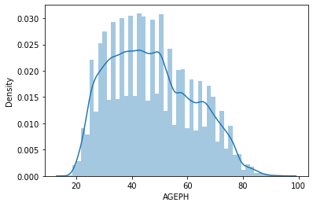

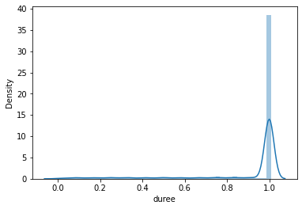

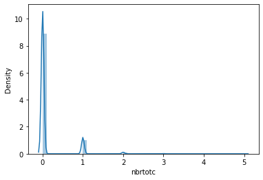

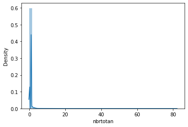

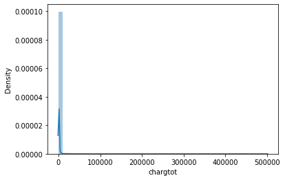

```python
plot_univariate_numerical_variables_distribution(df, numerical_variables, params)
```

```python
corr = df.corr()
corr.style.background_gradient(cmap='coolwarm')
```

|  | AGEPH | duree | lnexpo | nbrtotc | nbrtotan | chargtot |
| --- | --- | --- | --- | --- | --- | --- |
| AGEPH | 1.000000 | 0.099901 | 0.078857 | -0.069035 | -0.046285 | -0.016983 |
| duree | 0.099901 | 1.000000 | 0.913371 | 0.052203 | -0.076801 | 0.000247 |
| lnexpo | 0.078857 | 0.913371 | 1.000000 | 0.056768 | -0.085214 | 0.002479 |
| nbrtotc | -0.069035 | 0.052203 | 0.056768 | 1.000000 | 0.569537 | 0.164385 |
| nbrtotan | -0.046285 | -0.076801 | -0.085214 | 0.569537 | 1.000000 | 0.117699 |
| chargtot | -0.016983 | 0.000247 | 0.002479 | 0.164385 | 0.117699 | 1.000000 |

We notice that `nbrtotc` and `nbrtotan` are highly correlated (the same goes for `duree` and `lnexpo`)

## 1.2 univariate analysis of categorical data

```python
categorical_variables = list(df.select_dtypes(include=['object']).columns)
categorical_variables
```

```
['CODPOSS',
 'agecar',
 'sexp',
 'fuelc',
 'split',
 'usec',
 'fleetc',
 'sportc',
 'coverp',
 'powerc']
```

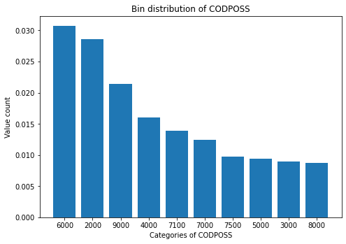

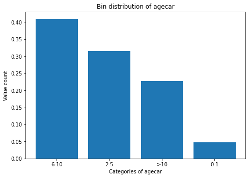

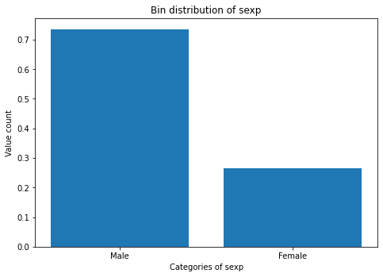

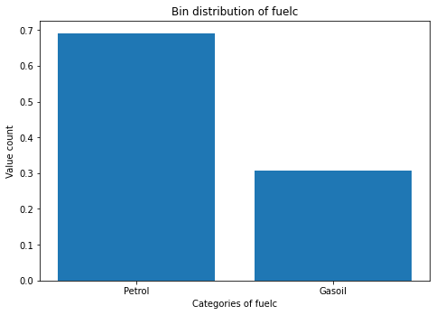

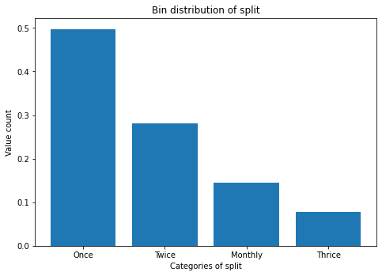

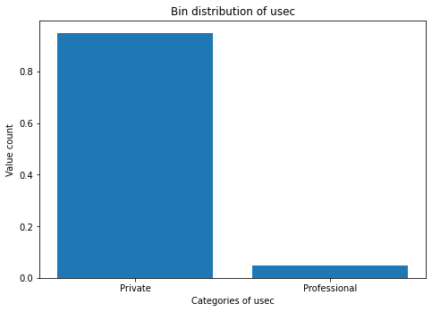

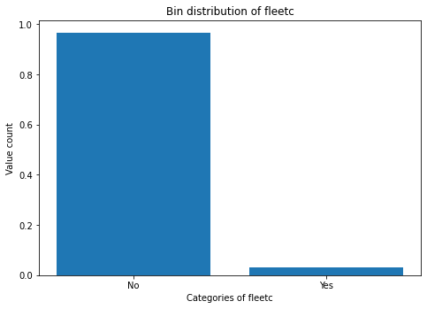

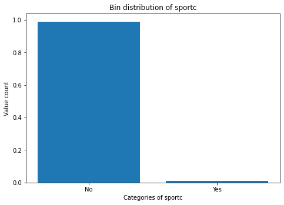

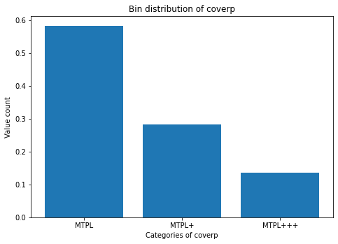

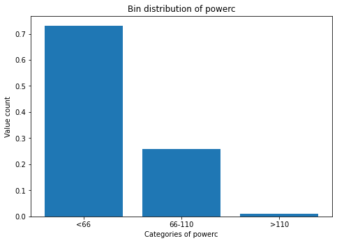

```python
plot_univariate_categorical_variables_distribution(df, categorical_variables, params)
```

## 1.3 bivariate analysis of numerical data

```python
nb_claims_name, claim_amount_name = params.get(Constants.NB_CLAIMS), params.get(Constants.CLAIM_AMOUNT)
claim_frequency_name = params.get(Constants.CLAIM_FREQUENCY)
```

```python
exposure_name = params.get(Constants.EXPOSURE_NAME)
```

```python
df[claim_frequency_name] = df[nb_claims_name]/df[exposure_name]
```

```python
df[[claim_frequency_name, exposure_name, nb_claims_name]].describe()
```

|  | claim_frequency | duree | nbrtotc |
| --- | --- | --- | --- |
| count | 163,657.00 | 163,657.00 | 163,657.00 |
| mean | 0.16 | 0.89 | 0.12 |
| std | 0.98 | 0.24 | 0.37 |
| min | 0.00 | 0.00 | 0.00 |
| 25% | 0.00 | 1.00 | 0.00 |
| 50% | 0.00 | 1.00 | 0.00 |
| 75% | 0.00 | 1.00 | 0.00 |
| max | 182.50 | 1.01 | 5.00 |

```python
df.groupby(nb_claims_name)[nb_claims_name, exposure_name, claim_frequency_name].agg(nb_claims=(nb_claims_name, 'count'),\
                                                                                    exposure=(exposure_name, 'sum'),\
                                                                                    frequency=(claim_frequency_name, 'mean'))
```

| nbrtotc | nb_claims | exposure | frequency |
| --- | --- | --- | --- |
| 0 | 145312 | 128,595.95 | 0.00 |
| 1 | 16602 | 15,410.32 | 1.29 |
| 2 | 1562 | 1,447.30 | 2.35 |
| 3 | 162 | 150.45 | 3.40 |
| 4 | 17 | 14.33 | 5.12 |
| 5 | 2 | 1.38 | 7.70 |

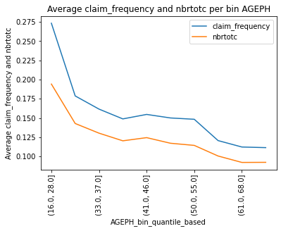

```python
plot_avg_target_per_numerical_bin(df, ['AGEPH'], params, target=claim_frequency_name)
```

**Some observations:**

- The variable `AGEPH` is almost monotonically decreasing, we observe a small bump between 41 and 55 yo.

```python
get_avg_target_per_numerical_bin(df, 'AGEPH', [nb_claims_name, claim_amount_name])
```

| AGEPH_bin_quantile_based | nbrtotc | chargtot |
| --- | --- | --- |
| (16.0, 28.0] | 0.19 | 364.28 |
| (28.0, 33.0] | 0.14 | 242.43 |
| (33.0, 37.0] | 0.13 | 159.98 |
| (37.0, 41.0] | 0.12 | 200.21 |
| (41.0, 46.0] | 0.12 | 222.06 |
| (46.0, 50.0] | 0.12 | 182.90 |
| (50.0, 55.0] | 0.11 | 148.41 |
| (55.0, 61.0] | 0.10 | 120.31 |
| (61.0, 68.0] | 0.09 | 112.86 |
| (68.0, 95.0] | 0.09 | 131.56 |

## 1.4 bivariate analysis of categorical data

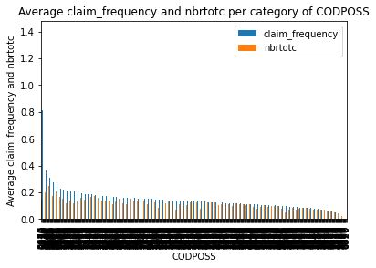

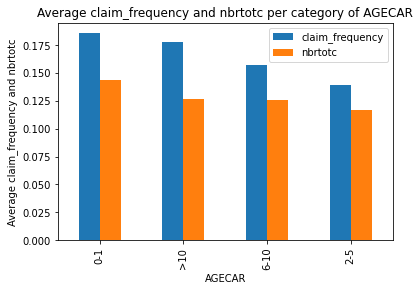

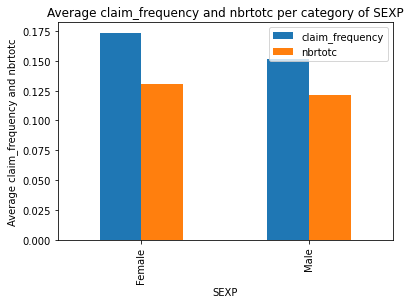

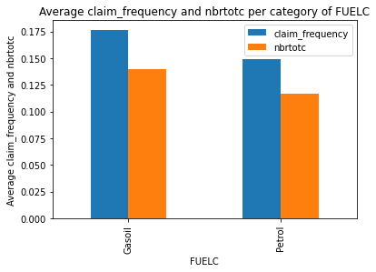

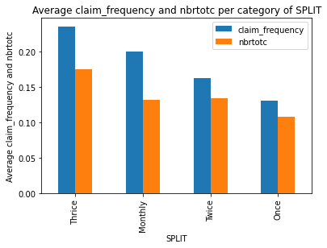

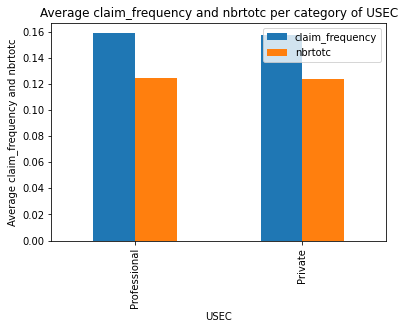

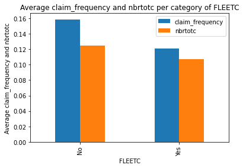

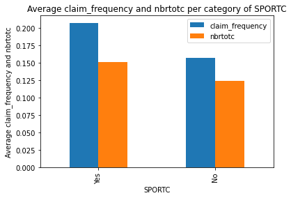

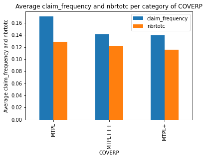

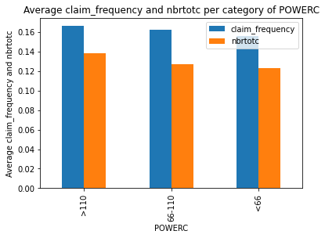

```python
plt_avg_target_per_category(df, categorical_variables, params, target=claim_frequency_name)
```

**Some observations:**

```python
for cat_var in categorical_variables:
    print(df.groupby(cat_var)[[claim_frequency_name,nb_claims_name, claim_amount_name]].mean().sort_values(by=[nb_claims_name, claim_amount_name], ascending=False))
    print('-'*100)
```

```
         claim_frequency  nbrtotc  chargtot
CODPOSS
6637                0.33     0.30     46.71
1210                0.45     0.29    285.30
1040                0.34     0.25    453.85
3040                0.37     0.25    333.48
3790                0.32     0.25    240.45
...                  ...      ...       ...
6887                0.00     0.00      0.00
6890                0.00     0.00      0.00
6970                0.00     0.00      0.00
8920                0.00     0.00      0.00
8957                0.00     0.00      0.00

[583 rows x 3 columns]
----------------------------------------------------------------------------------------------------
        claim_frequency  nbrtotc  chargtot
agecar
0-1                0.19     0.14    254.40
>10                0.18     0.13    201.37
6-10               0.16     0.13    197.88
2-5                0.14     0.12    168.18
----------------------------------------------------------------------------------------------------
        claim_frequency  nbrtotc  chargtot
sexp
Female             0.17     0.13    216.66
Male               0.15     0.12    183.15
----------------------------------------------------------------------------------------------------
        claim_frequency  nbrtotc  chargtot
fuelc
Gasoil             0.18     0.14    199.98
Petrol             0.15     0.12    188.44
----------------------------------------------------------------------------------------------------
         claim_frequency  nbrtotc  chargtot
split
Thrice              0.24     0.17    275.78
Twice               0.16     0.13    176.21
Monthly             0.20     0.13    216.16
Once                0.13     0.11    180.93
----------------------------------------------------------------------------------------------------
```

[output cut: 12 more lines]

```
Yes                0.21     0.15    236.33
No                 0.16     0.12    191.59
----------------------------------------------------------------------------------------------------
         claim_frequency  nbrtotc  chargtot
coverp
MTPL                0.17     0.13    205.67
MTPL+++             0.14     0.12    222.38
MTPL+               0.14     0.12    149.05
----------------------------------------------------------------------------------------------------
        claim_frequency  nbrtotc  chargtot
powerc
>110               0.17     0.14    323.30
66-110             0.16     0.13    214.53
<66                0.16     0.12    182.24
----------------------------------------------------------------------------------------------------
```

```python
# processing postcode data
postcode_mapping = pd.read_csv(params.get(Constants.LINK_TO_POSTAL_CODE_MAPPING), delimiter=';')
postcode_mapping.head(3)
```

|  | Code | Localite | Longitude | Latitude | Coordonnees | Geom |
| --- | --- | --- | --- | --- | --- | --- |
| 0 | 1050 | Ixelles | 4.38 | 50.82 | 50.8222854,4.3815707 | NaN |
| 1 | 1081 | Koekelberg | 4.33 | 50.86 | 50.8622633,4.3257084 | NaN |
| 2 | 1130 | Haren | 4.41 | 50.89 | 50.8919661,4.41257087324 | NaN |

```python
postcode_mapping['Code'] = postcode_mapping['Code'].astype('str')
```

```python
postcode_mapping_dic = {}
for code, district in zip(postcode_mapping.Code, postcode_mapping.Localite):
    if code not in postcode_mapping:
        postcode_mapping_dic[code]= district
```

```python
df['district'] = df.CODPOSS.replace(postcode_mapping_dic)
```

```python
avg_claim_per_district = df.groupby('district')[[claim_frequency_name,nb_claims_name, claim_amount_name]].mean().sort_values(by=[claim_frequency_name, claim_amount_name], ascending=False)
```

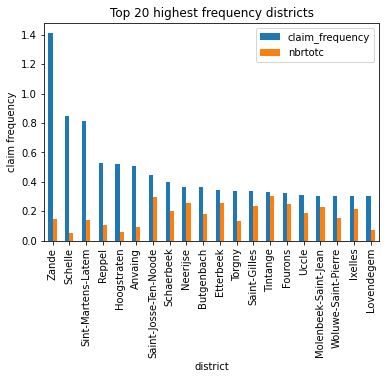

```python
avg_claim_per_district.head(20)[[claim_frequency_name, nb_claims_name]].plot.bar()
plt.title('Top 20 highest frequency districts')
plt.ylabel('claim frequency')
```

A lot of riskier district are from **Bruxelles** (ex: Sint-Josse, Schaerbeek, Etterbeek, Saint-Gilles, Uccle, Molenbeek, Woluwe, Ixelles)

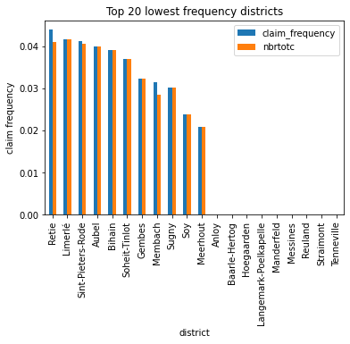

```python
avg_claim_per_district.tail(20)[[claim_frequency_name, nb_claims_name]].plot.bar()
plt.title('Top 20 lowest frequency districts')
plt.ylabel('claim frequency')
```

```python
#TODO: check the interactions between variables (probably interaction between age and sex and other properties of the car)
```

# 2. Feature Engineering

We decide to work only with categorical variables in order for faciliate the interpretation.

```python
for cat_var in categorical_variables:
    df[cat_var] = pd.Categorical(df[cat_var])
for num_var in numerical_variables:
    df[num_var] = pd.to_numeric(df[num_var])
```

```python
df, risk_group_mapping = apply_mean_hot_categorical_encoding(df, claim_frequency_name, 'district', nb_bin=3) #, risk_groups = ['A', 'B', 'C', 'D', 'E'])
```

In order to reduce the dimensionality, we proceed to a **mean-hot categorical encoding**. Based on the claim frequency, we want create three categories *high*, *medium* and *low* risk groups.

```python
for i,(district, risk_group) in enumerate(risk_group_mapping.items()):
    if i >20:
        break
    print(f'{district} ---> {risk_group}')
```

```
's Gravenwezel ---> high
Aalst ---> high
Aartselaar ---> medium
Aiseau ---> medium
Alken ---> medium
Alveringem ---> high
Anderlecht ---> high
Anderlues ---> medium
Anloy ---> low
Ans ---> medium
Anthisnes ---> low
Anthée ---> low
Antoing ---> low
Antwerpen ---> high
Anvaing ---> high
Arbrefontaine ---> medium
Ardooie ---> medium
Arendonk ---> low
As ---> high
Assenede ---> low
Assent ---> medium
```

```python
df = bin_numerical_variables(df, 'AGEPH', nb_bin=5)
```

```python
df.head()
```

|  | AGEPH | CODPOSS | duree | lnexpo | nbrtotc | nbrtotan | chargtot | agecar | sexp | fuelc | split | usec | fleetc | sportc | coverp | powerc | claim_frequency | district | district_risk_group | AGEPH_bin |
| --- | --- | --- | --- | --- | --- | --- | --- | --- | --- | --- | --- | --- | --- | --- | --- | --- | --- | --- | --- | --- |
| 0 | 64 | 1000 | 1.00 | 0.00 | 0 | 0.00 | 0.00 | 2-5 | Female | Petrol | Once | Private | No | No | MTPL+ | 66-110 | 0.00 | Bruxelles | high | (61.0, 95.0] |
| 1 | 28 | 1000 | 0.05 | -3.07 | 1 | 21.47 | 155.97 | 6-10 | Female | Petrol | Twice | Private | No | No | MTPL | 66-110 | 21.47 | Bruxelles | high | (16.999, 33.0] |
| 2 | 58 | 1000 | 0.40 | -0.91 | 0 | 0.00 | 0.00 | >10 | Female | Petrol | Thrice | Private | No | No | MTPL | <66 | 0.00 | Bruxelles | high | (50.0, 61.0] |
| 3 | 37 | 1030 | 0.17 | -1.77 | 0 | 0.00 | 0.00 | 2-5 | Female | Petrol | Once | Professional | No | No | MTPL+++ | 66-110 | 0.00 | Schaerbeek | high | (33.0, 41.0] |
| 4 | 29 | 1030 | 1.00 | 0.00 | 0 | 0.00 | 0.00 | 6-10 | Female | Petrol | Once | Private | No | No | MTPL+ | <66 | 0.00 | Schaerbeek | high | (16.999, 33.0] |

```python
df.dtypes
```

```
AGEPH                     int64
CODPOSS                category
duree                   float64
lnexpo                  float64
nbrtotc                   int64
nbrtotan                float64
chargtot                float64
agecar                 category
sexp                   category
fuelc                  category
split                  category
usec                   category
fleetc                 category
sportc                 category
coverp                 category
powerc                 category
claim_frequency         float64
district                 object
district_risk_group    category
AGEPH_bin              category
dtype: object
```

## 2.1 Processing with Binning continuous variables

```python
test_size, random_state = params.get(Constants.TEST_SIZE), params.get(Constants.RANDOM_STATE)
```

```python
df_cp = df.copy()
```

```python
df.columns
```

```
Index(['AGEPH', 'CODPOSS', 'duree', 'lnexpo', 'nbrtotc', 'nbrtotan',
       'chargtot', 'agecar', 'sexp', 'fuelc', 'split', 'usec', 'fleetc',
       'sportc', 'coverp', 'powerc', 'claim_frequency', 'district',
       'district_risk_group', 'AGEPH_bin'],
      dtype='object')
```

```python
#nb_claims, claim_amount, claim_frequency = df[nb_claims_name], df[claim_amount_name], df[claim_frequency_name]
#exposure = df[exposure_name]
```

```python
non_predictor_variables = [
                         #claim_amount_name, \
                           claim_frequency_name, \
                      #     nb_claims_name,
                           'nbrtotan',
                           'district',
                           'CODPOSS',
                            'AGEPH',
                           *params.get(Constants.VARIABLES_TO_EXCLUDE)]
```

```python
df_step1 =df.drop(columns=non_predictor_variables)
```

```python
df_step1.columns
```

```
Index(['duree', 'nbrtotc', 'chargtot', 'agecar', 'sexp', 'fuelc', 'split',
       'usec', 'fleetc', 'sportc', 'coverp', 'powerc', 'district_risk_group',
       'AGEPH_bin'],
      dtype='object')
```

```python
df_step1.dtypes
```

```
duree                   float64
nbrtotc                   int64
chargtot                float64
agecar                 category
sexp                   category
fuelc                  category
split                  category
usec                   category
fleetc                 category
sportc                 category
coverp                 category
powerc                 category
district_risk_group    category
AGEPH_bin              category
dtype: object
```

```python
get_distribution_info_for_categorical_variables(df_step1)
```

|  | nb_unique_categories | distribution |
| --- | --- | --- |
| agecar | 4 | {'6-10': '41.03%', '2-5': '31.50%', '>10': '22.72%', '0-1': '4.75%'} |
| sexp | 2 | {'Male': '73.59%', 'Female': '26.41%'} |
| fuelc | 2 | {'Petrol': '69.18%', 'Gasoil': '30.82%'} |
| split | 4 | {'Once': '49.79%', 'Twice': '28.08%', 'Monthly': '14.42%', 'Thrice': '7.71%'} |
| usec | 2 | {'Private': '95.11%', 'Professional': '4.89%'} |
| fleetc | 2 | {'No': '96.80%', 'Yes': '3.20%'} |
| sportc | 2 | {'No': '99.08%', 'Yes': '0.92%'} |
| coverp | 3 | {'MTPL': '58.30%', 'MTPL+': '28.15%', 'MTPL+++': '13.55%'} |
| powerc | 3 | {'<66': '73.21%', '66-110': '25.78%', '>110': '1.01%'} |
| district_risk_group | 3 | {'high': '45.56%', 'medium': '35.31%', 'low': '19.13%'} |
| AGEPH_bin | 5 | {'(16.999, 33.0]': '21.56%', '(41.0, 50.0]': '21.29%', '(61.0, 95.0]': '19.62%', '(50.0, 61.0]': '18.80%', '(33.0, 41.0]': '18.73%'} |

```python
df_step1
```

|  | duree | nbrtotc | chargtot | agecar | sexp | fuelc | split | usec | fleetc | sportc | coverp | powerc | district_risk_group | AGEPH_bin |
| --- | --- | --- | --- | --- | --- | --- | --- | --- | --- | --- | --- | --- | --- | --- |
| 0 | 1.00 | 0 | 0.00 | 2-5 | Female | Petrol | Once | Private | No | No | MTPL+ | 66-110 | high | (61.0, 95.0] |
| 1 | 0.05 | 1 | 155.97 | 6-10 | Female | Petrol | Twice | Private | No | No | MTPL | 66-110 | high | (16.999, 33.0] |
| 2 | 0.40 | 0 | 0.00 | >10 | Female | Petrol | Thrice | Private | No | No | MTPL | <66 | high | (50.0, 61.0] |
| 3 | 0.17 | 0 | 0.00 | 2-5 | Female | Petrol | Once | Professional | No | No | MTPL+++ | 66-110 | high | (33.0, 41.0] |
| 4 | 1.00 | 0 | 0.00 | 6-10 | Female | Petrol | Once | Private | No | No | MTPL+ | <66 | high | (16.999, 33.0] |
| ... | ... | ... | ... | ... | ... | ... | ... | ... | ... | ... | ... | ... | ... | ... |
| 163652 | 1.00 | 0 | 0.00 | 2-5 | Male | Petrol | Once | Private | No | No | MTPL+ | <66 | low | (41.0, 50.0] |
| 163653 | 1.00 | 0 | 0.00 | 6-10 | Male | Petrol | Once | Private | No | No | MTPL | <66 | low | (61.0, 95.0] |
| 163654 | 1.00 | 0 | 0.00 | 2-5 | Male | Petrol | Twice | Private | No | No | MTPL | <66 | low | (61.0, 95.0] |
| 163655 | 1.00 | 1 | 3,177.99 | >10 | Male | Petrol | Once | Private | Yes | No | MTPL | <66 | low | (50.0, 61.0] |
| 163656 | 1.00 | 2 | 13,818.23 | 2-5 | Male | Petrol | Once | Private | No | No | MTPL+++ | <66 | high | (16.999, 33.0] |

163657 rows × 14 columns

### 2.1.1 Dummy Coding with reference class

```python
df_step1_dummy = pd.get_dummies(df_step1)
```

```python
df_step1_dummy.shape
```

```
(163657, 35)
```

```python
reference_class_lst = get_reference_classes(df_step1, nb_claims_name, exposure_name)
```

```
The reference class of agecar is 2-5
The reference class of sexp is Male
The reference class of fuelc is Petrol
The reference class of split is Once
The reference class of usec is Private
The reference class of fleetc is Yes
The reference class of sportc is No
The reference class of coverp is MTPL+
The reference class of powerc is <66
The reference class of district_risk_group is low
The reference class of AGEPH_bin is (61.0, 95.0]
```

The policyholder belonging to all those classes is the less risky

```python
reference_class_lst
```

```
['agecar_2-5',
 'sexp_Male',
 'fuelc_Petrol',
 'split_Once',
 'usec_Private',
 'fleetc_Yes',
 'sportc_No',
 'coverp_MTPL+',
 'powerc_<66',
 'district_risk_group_low',
 'AGEPH_bin_(61.0, 95.0]']
```

```python
df_step1_dummy.head(3)
```

|  | duree | nbrtotc | chargtot | agecar_0-1 | agecar_2-5 | agecar_6-10 | agecar_>10 | sexp_Female | sexp_Male | fuelc_Gasoil | ... | powerc_<66 | powerc_>110 | district_risk_group_high | district_risk_group_low | district_risk_group_medium | AGEPH_bin_(16.999, 33.0] | AGEPH_bin_(33.0, 41.0] | AGEPH_bin_(41.0, 50.0] | AGEPH_bin_(50.0, 61.0] | AGEPH_bin_(61.0, 95.0] |
| --- | --- | --- | --- | --- | --- | --- | --- | --- | --- | --- | --- | --- | --- | --- | --- | --- | --- | --- | --- | --- | --- |
| 0 | 1.00 | 0 | 0.00 | 0 | 1 | 0 | 0 | 1 | 0 | 0 | ... | 0 | 0 | 1 | 0 | 0 | 0 | 0 | 0 | 0 | 1 |
| 1 | 0.05 | 1 | 155.97 | 0 | 0 | 1 | 0 | 1 | 0 | 0 | ... | 0 | 0 | 1 | 0 | 0 | 1 | 0 | 0 | 0 | 0 |
| 2 | 0.40 | 0 | 0.00 | 0 | 0 | 0 | 1 | 1 | 0 | 0 | ... | 1 | 0 | 1 | 0 | 0 | 0 | 0 | 0 | 1 | 0 |

3 rows × 35 columns

```python
DATASET = df_step1_dummy.drop(columns=reference_class_lst)
```

```python
DATASET.shape == (df_step1_dummy.shape[0], df_step1_dummy.shape[1] -len(reference_class_lst))
```

```
True
```

```python
DATASET.rename(columns=params.get(Constants.RENAMING_DUMMY_CODING_MAPPING), inplace=True)
```

```python
DATASET.head(3)
```

|  | duree | nbrtotc | chargtot | agecar_zero_one | agecar_six_ten | agecar_higher_ten | sexp_Female | fuelc_Gasoil | split_Monthly | split_Thrice | ... | coverp_MTPL | coverp_MTPLplusplusplus | powerc_sixtysix_onehundredten | powerc_higher_onehundredten | district_risk_group_high | district_risk_group_medium | AGEPH_bin_seventeen_thirtythree | AGEPH_bin_thirtythree_forty_one | AGEPH_bin_forty_one_fifty | AGEPH_bin_fifty_sixty_one |
| --- | --- | --- | --- | --- | --- | --- | --- | --- | --- | --- | --- | --- | --- | --- | --- | --- | --- | --- | --- | --- | --- |
| 0 | 1.00 | 0 | 0.00 | 0 | 0 | 0 | 1 | 0 | 0 | 0 | ... | 0 | 0 | 1 | 0 | 1 | 0 | 0 | 0 | 0 | 0 |
| 1 | 0.05 | 1 | 155.97 | 0 | 1 | 0 | 1 | 0 | 0 | 0 | ... | 1 | 0 | 1 | 0 | 1 | 0 | 1 | 0 | 0 | 0 |
| 2 | 0.40 | 0 | 0.00 | 0 | 0 | 1 | 1 | 0 | 0 | 1 | ... | 1 | 0 | 0 | 0 | 1 | 0 | 0 | 0 | 0 | 1 |

3 rows × 24 columns

```python
nb_claims, claim_amount = DATASET[nb_claims_name], DATASET[claim_amount_name]
X = DATASET.drop(columns=[nb_claims_name, claim_amount_name])
```

```python
X_train, X_test, y_train, y_test = train_test_split(X,nb_claims,test_size=test_size, random_state=random_state, stratify=nb_claims)
X_train_sev, X_test_sev, y_train_sev, y_test_sev = train_test_split(X,nb_claims,test_size=test_size, random_state=random_state, stratify=nb_claims)
```

# 3. Modelling

## 3.1 GLM frequency

We first calibrate the following GLM

$$N_i \sim \text{POI}(\mu_i)$$

where $$\mu_i = d_i \exp{(\beta \mathbb{I}(X_i))}$$ and $d_i$ is the exposure for record $i$.

```python
formula_freq = f'{nb_claims_name} ~ ' + ' + '.join( [c for c in X.columns if c!= exposure_name])
formula_freq
```

```
'nbrtotc ~ agecar_zero_one + agecar_six_ten + agecar_higher_ten + sexp_Female + fuelc_Gasoil + split_Monthly + split_Thrice + split_Twice + usec_Professional + fleetc_No + sportc_Yes + coverp_MTPL + coverp_MTPLplusplusplus + powerc_sixtysix_onehundredten + powerc_higher_onehundredten + district_risk…
```

```python
freq_glm = smf.glm(formula=formula_freq,
                   data=DATASET,
                   exposure=DATASET[exposure_name],
                   family = sm.families.Poisson(link=sm.families.links.log())
                  ).fit()
```

```python
print(freq_glm.summary())
```

```
                 Generalized Linear Model Regression Results
==============================================================================
Dep. Variable:                nbrtotc   No. Observations:               163657
Model:                            GLM   Df Residuals:                   163635
Model Family:                 Poisson   Df Model:                           21
Link Function:                    log   Scale:                          1.0000
Method:                          IRLS   Log-Likelihood:                -62725.
Date:                Sun, 16 Jan 2022   Deviance:                       87617.
Time:                        00:59:55   Pearson chi2:                 1.90e+05
No. Iterations:                     6   Pseudo R-squ. (CS):            0.01553
Covariance Type:            nonrobust
===================================================================================================
                                      coef    std err          z      P>|z|      [0.025      0.975]
---------------------------------------------------------------------------------------------------
Intercept                          -3.0442      0.052    -58.701      0.000      -3.146      -2.943
agecar_zero_one                     0.2431      0.033      7.382      0.000       0.179       0.308
agecar_six_ten                      0.0570      0.018      3.158      0.002       0.022       0.092
agecar_higher_ten                   0.0688      0.022      3.168      0.002       0.026       0.111
sexp_Female                         0.0459      0.016      2.845      0.004       0.014       0.078
fuelc_Gasoil                        0.1863      0.015     12.080      0.000       0.156       0.217
split_Monthly                       0.3358      0.021     15.636      0.000       0.294       0.378
split_Thrice                        0.3777      0.024     15.495      0.000       0.330       0.426
split_Twice                         0.1575      0.017      9.321      0.000       0.124       0.191
usec_Professional                   0.0307      0.033      0.928      0.353      -0.034       0.095
fleetc_No                           0.0874      0.043      2.017      0.044       0.002       0.172
sportc_Yes                          0.0778      0.071      1.104      0.270      -0.060       0.216
coverp_MTPL                         0.1442      0.017      8.361      0.000       0.110       0.178
coverp_MTPLplusplusplus            -0.0122      0.025     -0.482      0.630      -0.062       0.037
powerc_sixtysix_onehundredten       0.0896      0.017      5.316      0.000       0.057       0.123
powerc_higher_onehundredten         0.2536      0.070      3.601      0.000       0.116       0.392
district_risk_group_high            0.5438      0.022     25.197      0.000       0.502       0.586
district_risk_group_medium          0.2975      0.023     13.040      0.000       0.253       0.342
AGEPH_bin_seventeen_thirtythree     0.5534      0.023     23.633      0.000       0.508       0.599
AGEPH_bin_thirtythree_forty_one     0.2498      0.025      9.918      0.000       0.200       0.299
AGEPH_bin_forty_one_fifty           0.2275      0.024      9.292      0.000       0.179       0.275
AGEPH_bin_fifty_sixty_one           0.1197      0.026      4.687      0.000       0.070       0.170
===================================================================================================
```

We want to re-run the model by removing stepwise the feature with the highest p-value until we have only features with p-values lower than 0.05

```python
freq_glm_backward = run_glm_backward_selection(DATASET,
                                               X,
                                               params,
                                               nb_claims_name,
                                               family=sm.families.Poisson(link=sm.families.links.log()))
```

```
The feature coverp_MTPLplusplusplus is removed because it exhibited a p-value of 0.629676967182329>0.05
The feature usec_Professional is removed because it exhibited a p-value of 0.36860373195274676>0.05
The feature sportc_Yes is removed because it exhibited a p-value of 0.27298046041444946>0.05
```

```python
print(freq_glm_backward.summary())
```

```
                 Generalized Linear Model Regression Results
==============================================================================
Dep. Variable:                nbrtotc   No. Observations:               163657
Model:                            GLM   Df Residuals:                   163638
Model Family:                 Poisson   Df Model:                           18
Link Function:                    log   Scale:                          1.0000
Method:                          IRLS   Log-Likelihood:                -62726.
Date:                Sun, 16 Jan 2022   Deviance:                       87619.
Time:                        00:59:59   Pearson chi2:                 1.90e+05
No. Iterations:                     6   Pseudo R-squ. (CS):            0.01552
Covariance Type:            nonrobust
===================================================================================================
                                      coef    std err          z      P>|z|      [0.025      0.975]
---------------------------------------------------------------------------------------------------
Intercept                          -3.0450      0.051    -60.229      0.000      -3.144      -2.946
agecar_zero_one                     0.2403      0.033      7.361      0.000       0.176       0.304
agecar_six_ten                      0.0593      0.018      3.367      0.001       0.025       0.094
agecar_higher_ten                   0.0705      0.021      3.278      0.001       0.028       0.113
sexp_Female                         0.0455      0.016      2.818      0.005       0.014       0.077
fuelc_Gasoil                        0.1863      0.015     12.129      0.000       0.156       0.216
split_Monthly                       0.3340      0.021     15.617      0.000       0.292       0.376
split_Thrice                        0.3780      0.024     15.508      0.000       0.330       0.426
split_Twice                         0.1574      0.017      9.329      0.000       0.124       0.191
fleetc_No                           0.0850      0.043      1.969      0.049       0.000       0.170
coverp_MTPL                         0.1470      0.016      9.213      0.000       0.116       0.178
powerc_sixtysix_onehundredten       0.0926      0.017      5.571      0.000       0.060       0.125
powerc_higher_onehundredten         0.2792      0.067      4.168      0.000       0.148       0.410
district_risk_group_high            0.5438      0.022     25.199      0.000       0.502       0.586
district_risk_group_medium          0.2974      0.023     13.040      0.000       0.253       0.342
AGEPH_bin_seventeen_thirtythree     0.5542      0.023     23.706      0.000       0.508       0.600
AGEPH_bin_thirtythree_forty_one     0.2503      0.025      9.942      0.000       0.201       0.300
AGEPH_bin_forty_one_fifty           0.2278      0.024      9.309      0.000       0.180       0.276
AGEPH_bin_fifty_sixty_one           0.1202      0.026      4.708      0.000       0.070       0.170
===================================================================================================
```

```python
risk_factors_freq = pd.DataFrame(freq_glm_backward.params.sort_values(ascending=False), columns=['parameter'])
risk_factors_freq
```

|  | parameter |
| --- | --- |
| AGEPH_bin_seventeen_thirtythree | 0.55 |
| district_risk_group_high | 0.54 |
| split_Thrice | 0.38 |
| split_Monthly | 0.33 |
| district_risk_group_medium | 0.30 |
| powerc_higher_onehundredten | 0.28 |
| AGEPH_bin_thirtythree_forty_one | 0.25 |
| agecar_zero_one | 0.24 |
| AGEPH_bin_forty_one_fifty | 0.23 |
| fuelc_Gasoil | 0.19 |
| split_Twice | 0.16 |
| coverp_MTPL | 0.15 |
| AGEPH_bin_fifty_sixty_one | 0.12 |
| powerc_sixtysix_onehundredten | 0.09 |
| fleetc_No | 0.08 |
| agecar_higher_ten | 0.07 |
| agecar_six_ten | 0.06 |
| sexp_Female | 0.05 |
| Intercept | -3.05 |

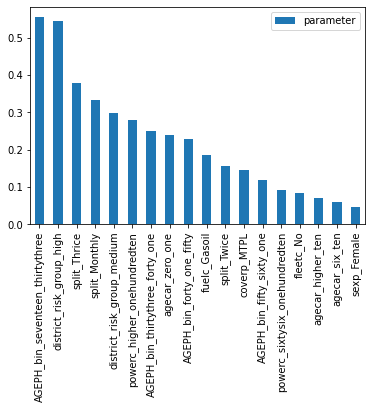

```python
risk_factors_freq.drop(index='Intercept').plot.bar()
```

*Observations:* `AGEPH_bin_seventeen_thirtythree` and `district_risk_group_high` are the two most important risk factors

## 3.2 GLM severity

```python
DATASET_SEVERITY = DATASET.query(f'{claim_amount_name}>0')
```

```python
DATASET_SEVERITY.index
```

```
Int64Index([     1,     12,     15,     20,     22,     23,     27,     28,
                29,     31,
            ...
            163569, 163579, 163599, 163603, 163610, 163624, 163636, 163642,
            163655, 163656],
           dtype='int64', length=18345)
```

```python
X_SEVERITY = X.loc[DATASET_SEVERITY.index, :]
```

```python
formula_sev = f'{claim_amount_name} ~ ' + ' + '.join( [c for c in X.columns if c!= exposure_name])
formula_sev
```

```
'chargtot ~ agecar_zero_one + agecar_six_ten + agecar_higher_ten + sexp_Female + fuelc_Gasoil + split_Monthly + split_Thrice + split_Twice + usec_Professional + fleetc_No + sportc_Yes + coverp_MTPL + coverp_MTPLplusplusplus + powerc_sixtysix_onehundredten + powerc_higher_onehundredten + district_ris…
```

```python
sev_glm = smf.glm(formula=formula_sev,
                   data=DATASET_SEVERITY,
                   exposure=DATASET_SEVERITY[exposure_name],
                   family = sm.families.Gamma(link=sm.families.links.log())
                  ).fit()
```

```python
print(sev_glm.summary())
```

```
                 Generalized Linear Model Regression Results
==============================================================================
Dep. Variable:               chargtot   No. Observations:                18345
Model:                            GLM   Df Residuals:                    18323
Model Family:                   Gamma   Df Model:                           21
Link Function:                    log   Scale:                          69.963
Method:                          IRLS   Log-Likelihood:            -1.9308e+05
Date:                Sun, 16 Jan 2022   Deviance:                       55379.
Time:                        01:00:00   Pearson chi2:                 1.28e+06
No. Iterations:                    69   Pseudo R-squ. (CS):           0.003151
Covariance Type:            nonrobust
===================================================================================================
                                      coef    std err          z      P>|z|      [0.025      0.975]
---------------------------------------------------------------------------------------------------
Intercept                           6.5966      0.447     14.774      0.000       5.721       7.472
agecar_zero_one                     0.4090      0.290      1.409      0.159      -0.160       0.978
agecar_six_ten                     -0.0113      0.158     -0.071      0.943      -0.321       0.299
agecar_higher_ten                   0.1752      0.191      0.916      0.360      -0.200       0.550
sexp_Female                         0.1265      0.141      0.895      0.371      -0.151       0.404
fuelc_Gasoil                       -0.0559      0.136     -0.413      0.680      -0.322       0.210
split_Monthly                       0.0826      0.189      0.437      0.662      -0.288       0.453
split_Thrice                       -0.0779      0.218     -0.357      0.721      -0.505       0.349
split_Twice                        -0.4142      0.149     -2.782      0.005      -0.706      -0.122
usec_Professional                  -0.0276      0.292     -0.095      0.925      -0.599       0.544
fleetc_No                           0.3183      0.378      0.842      0.400      -0.422       1.059
sportc_Yes                         -0.3672      0.618     -0.594      0.553      -1.579       0.844
coverp_MTPL                         0.3324      0.152      2.183      0.029       0.034       0.631
coverp_MTPLplusplusplus             0.3244      0.219      1.478      0.139      -0.106       0.755
powerc_sixtysix_onehundredten       0.3775      0.148      2.545      0.011       0.087       0.668
powerc_higher_onehundredten         0.3441      0.622      0.554      0.580      -0.874       1.562
district_risk_group_high            0.4588      0.188      2.439      0.015       0.090       0.827
district_risk_group_medium          0.4009      0.198      2.022      0.043       0.012       0.790
AGEPH_bin_seventeen_thirtythree     0.5312      0.205      2.590      0.010       0.129       0.933
AGEPH_bin_thirtythree_forty_one     0.2036      0.220      0.927      0.354      -0.227       0.634
AGEPH_bin_forty_one_fifty           0.2530      0.214      1.185      0.236      -0.166       0.672
AGEPH_bin_fifty_sixty_one          -0.0498      0.223     -0.223      0.823      -0.486       0.387
===================================================================================================
```

```python
sev_glm_backward = run_glm_backward_selection(DATASET_SEVERITY,
                                               X_SEVERITY,
                                               params,
                                               claim_amount_name,
                                               family=sm.families.Gamma(link=sm.families.links.log()))
```

```
The feature agecar_six_ten is removed because it exhibited a p-value of 0.9432424682704508>0.05
The feature usec_Professional is removed because it exhibited a p-value of 0.9218637753798885>0.05
The feature AGEPH_bin_fifty_sixty_one is removed because it exhibited a p-value of 0.8219866304667723>0.05
The feature split_Thrice is removed because it exhibited a p-value of 0.6886291586798823>0.05
The feature fuelc_Gasoil is removed because it exhibited a p-value of 0.6767047329875635>0.05
The feature split_Monthly is removed because it exhibited a p-value of 0.5843584434689186>0.05
The feature powerc_higher_onehundredten is removed because it exhibited a p-value of 0.5455287223681258>0.05
The feature sportc_Yes is removed because it exhibited a p-value of 0.6567633169116456>0.05
The feature fleetc_No is removed because it exhibited a p-value of 0.37677636888264787>0.05
The feature sexp_Female is removed because it exhibited a p-value of 0.3331198648994337>0.05
The feature agecar_higher_ten is removed because it exhibited a p-value of 0.21702412478784505>0.05
The feature agecar_zero_one is removed because it exhibited a p-value of 0.15512342183566757>0.05
The feature AGEPH_bin_thirtythree_forty_one is removed because it exhibited a p-value of 0.1786618035209938>0.05
The feature AGEPH_bin_forty_one_fifty is removed because it exhibited a p-value of 0.29641079979721785>0.05
The feature coverp_MTPLplusplusplus is removed because it exhibited a p-value of 0.07244439392192742>0.05
The feature coverp_MTPL is removed because it exhibited a p-value of 0.0635200712878563>0.05
The feature district_risk_group_medium is removed because it exhibited a p-value of 0.06618064749452718>0.05
The feature district_risk_group_high is removed because it exhibited a p-value of 0.13897534364409012>0.05
```

```python
print(sev_glm_backward.summary())
```

```
                 Generalized Linear Model Regression Results
==============================================================================
Dep. Variable:               chargtot   No. Observations:                18345
Model:                            GLM   Df Residuals:                    18341
Model Family:                   Gamma   Df Model:                            3
Link Function:                    log   Scale:                          85.208
Method:                          IRLS   Log-Likelihood:            -1.9646e+05
Date:                Sun, 16 Jan 2022   Deviance:                       56990.
Time:                        01:00:05   Pearson chi2:                 1.56e+06
No. Iterations:                    16   Pseudo R-squ. (CS):           0.001559
Covariance Type:            nonrobust
===================================================================================================
                                      coef    std err          z      P>|z|      [0.025      0.975]
---------------------------------------------------------------------------------------------------
Intercept                           7.7415      0.101     76.801      0.000       7.544       7.939
split_Twice                        -0.4425      0.149     -2.969      0.003      -0.735      -0.150
powerc_sixtysix_onehundredten       0.4174      0.155      2.696      0.007       0.114       0.721
AGEPH_bin_seventeen_thirtythree     0.4824      0.152      3.183      0.001       0.185       0.779
===================================================================================================
```

The two variables `AGEPH_bin_seventeen_thirtythree` and `powerc_sixtysix_onehundredten` make the severity increase

## 3.3 Elastic Net (Lasso)

{statsmodels} and {statsmodels.formula.api} allow to fit GLMs with an elastic net penalty. The following penalized loss function is then minimized: $$-\frac{1}{n}\log \mathcal{L}(\beta_0,\mathbf{\beta}; \mathbf{X},y) + \alpha \cdot \left( \lambda ||\mathbf{\beta}||_1 + \frac{1-\lambda}{2}||\mathbf{\beta}||_2^2 \right),$$ where $\alpha$ is the penalty weight and $\lambda$ determines the weight of the $\ell_1$ versus $\ell_2$ norm. More details are [here](https://www.statsmodels.org/dev/generated/statsmodels.genmod.generalized_linear_model.GLM.fit_regularized.html).

### 3.3.1 LASSO Frequency

```python
reg_results, deviances = run_hyperparameter_search_regularized_model(formula_freq,
                                  DATASET,
                                  DATASET[exposure_name],
                                  sm.families.Poisson(link=sm.families.links.log()),
                                  alpha_range=list(np.arange(0,0.1, 0.001)),
                                  L1_wt=1,
                                  target=nb_claims_name,
                                  loss_function=mean_poisson_deviance)
```

```
100%|████████████████████████████████████████████████████████████████████████████████████████████████████████████████████████████████████████| 100/100 [08:28<00:00,  5.09s/it]
```

```python
reg_results
```

|  | Intercept | agecar_zero_one | agecar_six_ten | agecar_higher_ten | sexp_Female | fuelc_Gasoil | split_Monthly | split_Thrice | split_Twice | usec_Professional | ... | coverp_MTPL | coverp_MTPLplusplusplus | powerc_sixtysix_onehundredten | powerc_higher_onehundredten | district_risk_group_high | district_risk_group_medium | AGEPH_bin_seventeen_thirtythree | AGEPH_bin_thirtythree_forty_one | AGEPH_bin_forty_one_fifty | AGEPH_bin_fifty_sixty_one |
| --- | --- | --- | --- | --- | --- | --- | --- | --- | --- | --- | --- | --- | --- | --- | --- | --- | --- | --- | --- | --- | --- |
| 0.00 | -2.65 | 0.25 | 0.06 | 0.07 | 0.05 | 0.19 | 0.36 | 0.40 | 0.17 | 0.02 | ... | 0.12 | -0.05 | 0.08 | 0.25 | 0.46 | 0.22 | 0.46 | 0.15 | 0.13 | 0.03 |
| 0.00 | -2.17 | 0.00 | 0.00 | 0.00 | 0.00 | 0.00 | 0.00 | 0.00 | 0.00 | 0.00 | ... | 0.00 | 0.00 | 0.00 | 0.00 | 0.28 | 0.00 | 0.39 | 0.00 | 0.00 | -0.04 |
| 0.00 | -2.14 | 0.00 | 0.00 | 0.00 | 0.00 | 0.00 | 0.00 | 0.00 | 0.00 | 0.00 | ... | 0.00 | 0.00 | 0.00 | 0.00 | 0.23 | 0.00 | 0.34 | 0.00 | 0.00 | -0.00 |
| 0.00 | -2.00 | 0.00 | 0.00 | 0.00 | 0.00 | 0.00 | 0.00 | 0.00 | 0.00 | 0.00 | ... | 0.00 | 0.00 | 0.00 | 0.00 | 0.00 | -0.05 | 0.30 | 0.00 | 0.00 | 0.00 |
| 0.00 | -1.99 | 0.00 | 0.00 | 0.00 | 0.00 | 0.00 | 0.00 | 0.00 | 0.00 | 0.00 | ... | 0.00 | 0.00 | 0.00 | 0.00 | 0.00 | -0.02 | 0.25 | 0.00 | 0.00 | 0.00 |
| ... | ... | ... | ... | ... | ... | ... | ... | ... | ... | ... | ... | ... | ... | ... | ... | ... | ... | ... | ... | ... | ... |
| 0.10 | -1.40 | 0.00 | 0.00 | 0.00 | 0.00 | 0.00 | 0.00 | 0.00 | 0.00 | 0.00 | ... | 0.00 | 0.00 | 0.00 | 0.00 | 0.00 | 0.00 | 0.00 | 0.00 | 0.00 | 0.00 |
| 0.10 | -1.40 | 0.00 | 0.00 | 0.00 | 0.00 | 0.00 | 0.00 | 0.00 | 0.00 | 0.00 | ... | 0.00 | 0.00 | 0.00 | 0.00 | 0.00 | 0.00 | 0.00 | 0.00 | 0.00 | 0.00 |
| 0.10 | -1.39 | 0.00 | 0.00 | 0.00 | 0.00 | 0.00 | 0.00 | 0.00 | 0.00 | 0.00 | ... | 0.00 | 0.00 | 0.00 | 0.00 | 0.00 | 0.00 | 0.00 | 0.00 | 0.00 | 0.00 |
| 0.10 | -1.39 | 0.00 | 0.00 | 0.00 | 0.00 | 0.00 | 0.00 | 0.00 | 0.00 | 0.00 | ... | 0.00 | 0.00 | 0.00 | 0.00 | 0.00 | 0.00 | 0.00 | 0.00 | 0.00 | 0.00 |
| 0.10 | -1.38 | 0.00 | 0.00 | 0.00 | 0.00 | 0.00 | 0.00 | 0.00 | 0.00 | 0.00 | ... | 0.00 | 0.00 | 0.00 | 0.00 | 0.00 | 0.00 | 0.00 | 0.00 | 0.00 | 0.00 |

100 rows × 22 columns

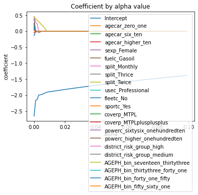

```python
plot_params_vs_alpha(reg_results)
```

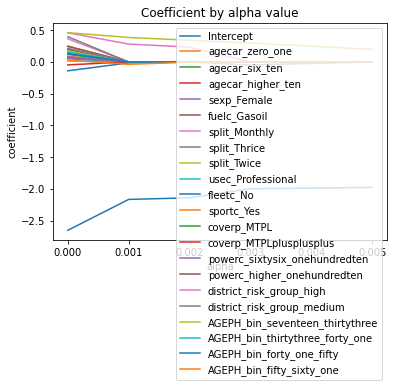

```python
plot_params_vs_alpha(reg_results.loc[0:0.005, :])
```

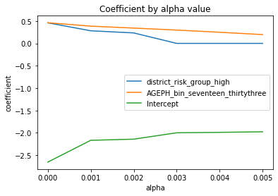

```python
plot_params_vs_alpha(reg_results.loc[0:0.005, ['district_risk_group_high', 'AGEPH_bin_seventeen_thirtythree', 'Intercept']])
```

*Observations:*

- `district_risk_group_high`
- `AGEPH_bin_seventeen_thirtythree`
- `Intercept`\ variables are the features whose coefficients resist the most to the regularization and converge less rapidly to zero

```python
deviances_df = pd.DataFrame(deviances)
deviances_df.query(f'deviance=={deviances_df.deviance.min()}')
```

|  | deviance | alpha | L1_wt |
| --- | --- | --- | --- |
| 0 | 0.54 | 0.00 | 1 |

We see that the regularisation did not add any value, a way to improve the results will be to take a smaller alpha step or to optimize over `L1_wt` as well

### 3.3.2 LASSO Severity

```python
reg_results_sev, deviances_sev = run_hyperparameter_search_regularized_model(formula_sev,
                                  DATASET_SEVERITY,
                                  DATASET_SEVERITY[exposure_name],
                                  sm.families.Gamma(link=sm.families.links.log()),
                                  alpha_range=list(np.arange(0,0.1, 0.001)),
                                  L1_wt=1,
                                  target=claim_amount_name,
                                  loss_function=mean_gamma_deviance)
```

```
100%|████████████████████████████████████████████████████████████████████████████████████████████████████████████████████████████████████████| 100/100 [04:44<00:00,  2.84s/it]
```

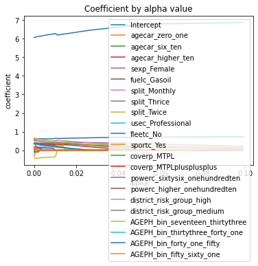

```python
plot_params_vs_alpha(reg_results_sev)
```

# TODO:should perform an hyperparameter search not only on alpha but also on L1_wt for the elastic search

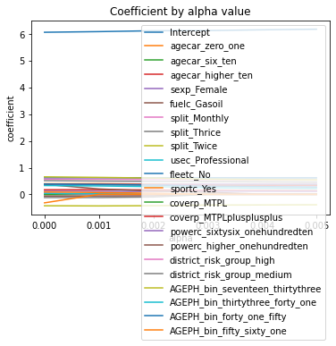

```python
plot_params_vs_alpha(reg_results_sev.loc[0:0.005,:])
```

```python
deviances_df_sev = pd.DataFrame(deviances)
deviances_df_sev.query(f'deviance=={deviances_df_sev.deviance.min()}')
```

|  | deviance | alpha | L1_wt |
| --- | --- | --- | --- |
| 0 | 0.54 | 0.00 | 1 |

# 4. Conclusion

*Frequency*

  *Ways of improvments* :
  - We did not aim at improving the performance of the model but only to understand the risk factors.
    - We could have tried keeping the continuous variables as such
    - We could have tried to proceed to model assessment on train/validation/test set for hyperparameter search
  - We could have tried to look for interactions between variables
  - We kept the same reference class for both `nb_claims` and `claim_amount`, we could have used distinct ones
  - We could have infer other variables if provided with better geo-mapping
  - An hyperparameter search for smaller alpha and the elastic net $\lambda $ parameter could have been performed...
  - A Pipeline could have been built to avoid data leakage